# Predicting Car Prices

# Set a working directory

```r
setwd(dir = "C:/Users/david/OneDrive/Documents/ULMS/PhD/Jobs/src/career_track/ds_projects/car_prices/")
```

# Load the necessary libraries

```r
library(tidyverse)
library(ggplot2)
library(corrplot)
library(statar)
library(caret)
```

# Import and view the data

The dataset is got from the 1985 Ward’s Automotive Yearbook and can be downloaded [here](https://archive.ics.uci.edu/dataset/10/automobile). There are `204` rows and `26` columns in the dataset. It contains both numerical and categorical variables.

```r
cars <- read_csv(file = "cars_data.csv", col_names = TRUE) %>%
  select(
    c(price = `13495`, symboling = `3`, normalised_losses = `?`, make = "alfa-romero", fuel_type = "gas",
      aspiration = "std", num_of_doors = "four", body_style = "convertible", engine_location = "front",
      drive_wheels = "rwd", wheel_base = `88.60`, length = `168.80`, width = `64.10`, height = `48.80`,
      curb_weight = `2548`, engine_type = "dohc", num_of_cylinders = "four", engine_size = `130`,
      fuel_system = "mpfi", compression_ratio = `9.00`, bore = `3.47`, stroke = `2.68`, horsepower = `111`,
      peak_rpm = `5000`, city_mpg = `21`, highway_mpg = `27`)
  )
head(cars)
```

| price | symboling | normalised_losses | make | fuel_type | aspiration | num_of_doors | body_style | engine_location | drive_wheels | wheel_base | length | width | height | curb_weight | engine_type | num_of_cylinders | engine_size | fuel_system | compression_ratio | bore | stroke | horsepower | peak_rpm | city_mpg | highway_mpg |
| --- | --- | --- | --- | --- | --- | --- | --- | --- | --- | --- | --- | --- | --- | --- | --- | --- | --- | --- | --- | --- | --- | --- | --- | --- | --- |
| 16500 | 3 | ? | alfa-romero | gas | std | four | convertible | front | rwd | 88.6 | 168.8 | 64.1 | 48.8 | 2548 | dohc | four | 130 | mpfi | 9.0 | 3.47 | 2.68 | 111 | 5000 | 21 | 27 |
| 16500 | 1 | ? | alfa-romero | gas | std | six | hatchback | front | rwd | 94.5 | 171.2 | 65.5 | 52.4 | 2823 | ohcv | six | 152 | mpfi | 9.0 | 2.68 | 3.47 | 154 | 5000 | 19 | 26 |
| 13950 | 2 | 164 | audi | gas | std | four | sedan | front | fwd | 99.8 | 176.6 | 66.2 | 54.3 | 2337 | ohc | four | 109 | mpfi | 10.0 | 3.19 | 3.40 | 102 | 5500 | 24 | 30 |
| 17450 | 2 | 164 | audi | gas | std | five | sedan | front | 4wd | 99.4 | 176.6 | 66.4 | 54.3 | 2824 | ohc | five | 136 | mpfi | 8.0 | 3.19 | 3.40 | 115 | 5500 | 18 | 22 |
| 15250 | 2 | ? | audi | gas | std | five | sedan | front | fwd | 99.8 | 177.3 | 66.3 | 53.1 | 2507 | ohc | five | 136 | mpfi | 8.5 | 3.19 | 3.40 | 110 | 5500 | 19 | 25 |
| 17710 | 1 | 158 | audi | gas | std | five | sedan | front | fwd | 105.8 | 192.7 | 71.4 | 55.7 | 2844 | ohc | five | 136 | mpfi | 8.5 | 3.19 | 3.40 | 110 | 5500 | 19 | 25 |

```r
glimpse(cars)
```

```
Rows: 204
Columns: 26
$ price             <chr> "16500", "16500", "13950", "17450", "15250", "17710"…
$ symboling         <dbl> 3, 1, 2, 2, 2, 1, 1, 1, 0, 2, 0, 0, 0, 1, 0, 0, 0, 2…
$ normalised_losses <chr> "?", "?", "164", "164", "?", "158", "?", "158", "?",…
$ make              <chr> "alfa-romero", "alfa-romero", "audi", "audi", "audi"…
$ fuel_type         <chr> "gas", "gas", "gas", "gas", "gas", "gas", "gas", "ga…
$ aspiration        <chr> "std", "std", "std", "std", "std", "std", "std", "tu…
$ num_of_doors      <chr> "four", "six", "four", "five", "five", "five", "five…
$ body_style        <chr> "convertible", "hatchback", "sedan", "sedan", "sedan…
$ engine_location   <chr> "front", "front", "front", "front", "front", "front"…
$ drive_wheels      <chr> "rwd", "rwd", "fwd", "4wd", "fwd", "fwd", "fwd", "fw…
$ wheel_base        <dbl> 88.6, 94.5, 99.8, 99.4, 99.8, 105.8, 105.8, 105.8, 9…
$ length            <dbl> 168.8, 171.2, 176.6, 176.6, 177.3, 192.7, 192.7, 192…
$ width             <dbl> 64.1, 65.5, 66.2, 66.4, 66.3, 71.4, 71.4, 71.4, 67.9…
$ height            <dbl> 48.8, 52.4, 54.3, 54.3, 53.1, 55.7, 55.7, 55.9, 52.0…
$ curb_weight       <dbl> 2548, 2823, 2337, 2824, 2507, 2844, 2954, 3086, 3053…
$ engine_type       <chr> "dohc", "ohcv", "ohc", "ohc", "ohc", "ohc", "ohc", "…
$ num_of_cylinders  <chr> "four", "six", "four", "five", "five", "five", "five…
$ engine_size       <dbl> 130, 152, 109, 136, 136, 136, 136, 131, 131, 108, 10…
$ fuel_system       <chr> "mpfi", "mpfi", "mpfi", "mpfi", "mpfi", "mpfi", "mpf…
$ compression_ratio <dbl> 9.00, 9.00, 10.00, 8.00, 8.50, 8.50, 8.50, 8.30, 7.0…
$ bore              <chr> "3.47", "2.68", "3.19", "3.19", "3.19", "3.19", "3.1…
$ stroke            <chr> "2.68", "3.47", "3.40", "3.40", "3.40", "3.40", "3.4…
$ horsepower        <chr> "111", "154", "102", "115", "110", "110", "110", "14…
$ peak_rpm          <chr> "5000", "5000", "5500", "5500", "5500", "5500", "550…
$ city_mpg          <dbl> 21, 19, 24, 18, 19, 19, 19, 17, 16, 23, 23, 21, 21, …
$ highway_mpg       <dbl> 27, 26, 30, 22, 25, 25, 25, 20, 22, 29, 29, 28, 28, …
```

# Checking and Handling NAs

There are `56` NA values in the dataset, which is coded as a dummy variable of “na_values”. The NAs consists of only `1%` of the dataset.

```r
cars[cars == "?"] <- NA

cars <- cars %>%
  mutate(
    normalised_losses = as.numeric(as.character(normalised_losses)),
    bore = as.numeric(as.character(bore)),
    stroke = as.numeric(as.character(stroke)),
    horsepower = as.numeric(as.character(horsepower)),
    peak_rpm = as.numeric(as.character(peak_rpm)),
    price = as.numeric(as.character(price)),
    na_values = ifelse(rowSums(is.na(.)) > 0, yes = "yes", no = "no")
  )

table(cars$na_values)
```

```
 no yes
160  44
```

```r
na_columns <- colnames(cars)[which(colSums(is.na(cars)) > 0)]
sum(is.na(cars))
```

```
[1] 56
```

```r
round(mean(is.na(cars)), digits = 2) # mean of NAs in the dataset
```

```
[1] 0.01
```

```r
# Percent of NAs in each column
num_na_cols <- sapply(cars, function(x) sum(is.na(x)))
na_columns_percent <- num_na_cols / nrow(cars) * 100
round(na_columns_percent, digits = 2)
```

```
            price         symboling normalised_losses              make
             1.96              0.00             19.61              0.00
        fuel_type        aspiration      num_of_doors        body_style
             0.00              0.00              0.00              0.00
  engine_location      drive_wheels        wheel_base            length
             0.00              0.00              0.00              0.00
            width            height       curb_weight       engine_type
             0.00              0.00              0.00              0.00
 num_of_cylinders       engine_size       fuel_system compression_ratio
             0.00              0.00              0.00              0.00
             bore            stroke        horsepower          peak_rpm
             1.96              1.96              0.98              0.98
         city_mpg       highway_mpg         na_values
             0.00              0.00              0.00
```

Learning the distribution of NA columns. This will determine how to impute NA values.

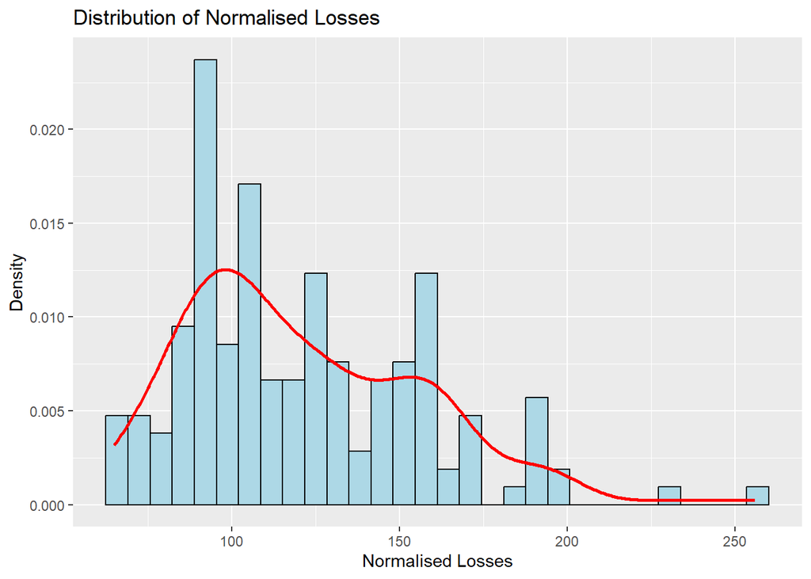

```r
ggplot(cars %>% na.omit(normalised_losses), aes(x = normalised_losses)) +
  geom_histogram(aes(y = ..density..), color = "black", fill = "lightblue") +
  geom_density(color = "red", size = 1) +
  labs(title = "Distribution of Normalised Losses", x = "Normalised Losses", y = "Density")
```

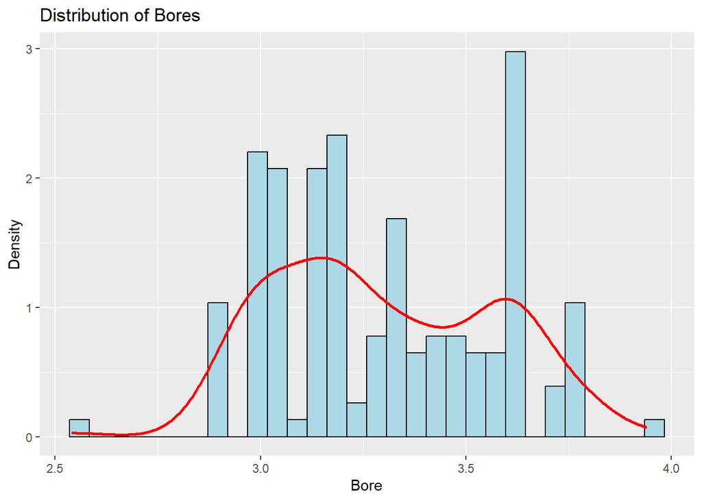

```r
ggplot(cars %>% na.omit(bore), aes(x = bore)) +
  geom_histogram(aes(y = ..density..), color = "black", fill = "lightblue") +
  geom_density(color = "red", size = 1) +
  labs(title = "Distribution of Bores", x = "Bore", y = "Density")
```

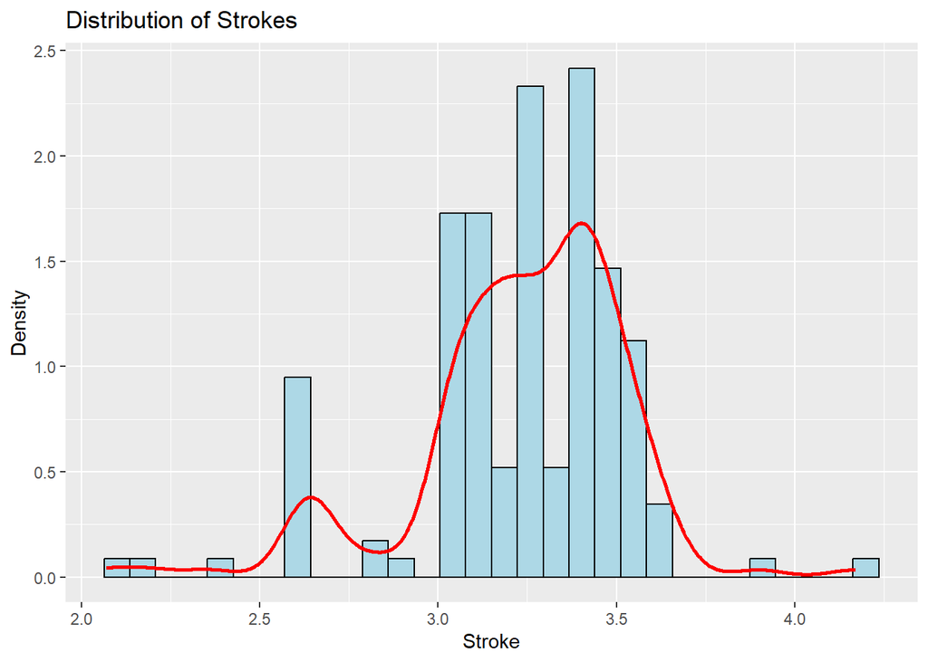

```r
ggplot(cars %>% na.omit(stroke), aes(x = stroke)) +
  geom_histogram(aes(y = ..density..), color = "black", fill = "lightblue") +
  geom_density(color = "red", size = 1) +
  labs(title = "Distribution of Strokes", x = "Stroke", y = "Density")
```

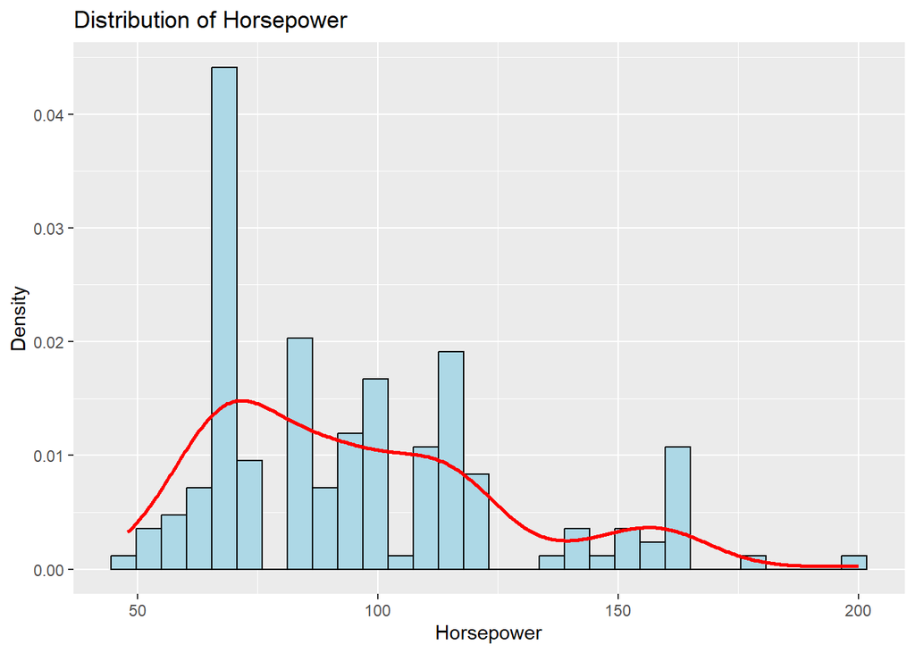

```r
ggplot(cars %>% na.omit(), aes(x = horsepower)) +
  geom_histogram(aes(y = ..density..), color = "black", fill = "lightblue") +
  geom_density(color = "red", size = 1) +
  labs(title = "Distribution of Horsepower", x = "Horsepower", y = "Density")
```

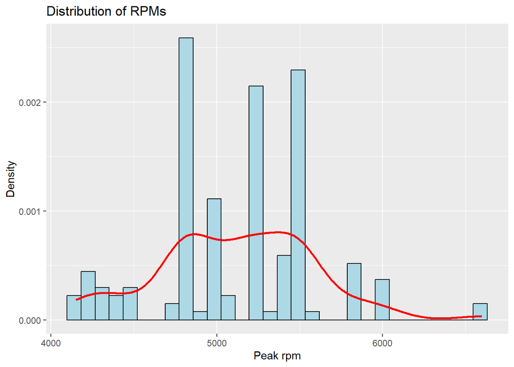

```r
ggplot(cars %>% na.omit(), aes(x = peak_rpm)) +
  geom_histogram(aes(y = ..density..), color = "black", fill = "lightblue") +
  geom_density(color = "red", size = 1) +
  labs(title = "Distribution of RPMs", x = "Peak rpm", y = "Density")
```

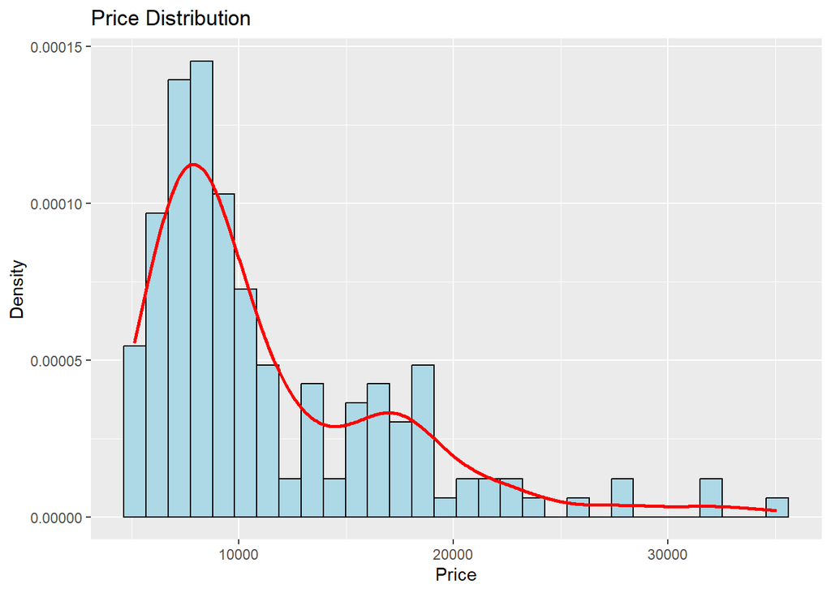

```r
ggplot(cars %>% na.omit(), aes(x = price)) +
  geom_histogram(aes(y = ..density..), color = "black", fill = "lightblue") +
  geom_density(color = "red", size = 1) +
  labs(title = "Price Distribution", x = "Price", y = "Density")
```

```r
cars <- cars %>%
  mutate(
    normalised_losses = ifelse(test = is.na(normalised_losses),
                               yes = round(median(normalised_losses, na.rm = TRUE), digits = 0),
                               no = normalised_losses),
    bore = ifelse(test = is.na(bore),
                  yes = round(median(bore, na.rm = TRUE), digits = 0),
                  no = bore),
    stroke = ifelse(test = is.na(stroke),
                    yes = round(median(stroke, na.rm = TRUE), digits = 0),
                    no = stroke),
    horsepower = ifelse(test = is.na(horsepower),
                        yes = round(median(horsepower, na.rm = TRUE), digits = 0),
                        no = horsepower),
    peak_rpm = ifelse(test = is.na(peak_rpm),
                      yes = round(mean(peak_rpm, na.rm = TRUE), digits = 0),
                      no = peak_rpm),
    price = ifelse(test = is.na(price),
                   yes = round(median(price, na.rm = TRUE), digits = 0),
                   no = price),
  ) %>%
  group_by(make)

sum(is.na(cars))
```

```
[1] 0
```

```r
sapply(cars, function(x) sum(is.na(x)))
```

```
            price         symboling normalised_losses              make
                0                 0                 0                 0
        fuel_type        aspiration      num_of_doors        body_style
                0                 0                 0                 0
  engine_location      drive_wheels        wheel_base            length
                0                 0                 0                 0
            width            height       curb_weight       engine_type
                0                 0                 0                 0
 num_of_cylinders       engine_size       fuel_system compression_ratio
                0                 0                 0                 0
             bore            stroke        horsepower          peak_rpm
                0                 0                 0                 0
         city_mpg       highway_mpg         na_values
                0                 0                 0
```

# Checking for outliers in price

The median price of a car is `$10,270` and the average price is `$13148`. Clearly, we see that the price is concentrated between the minimum price of `$5,118` and just under `$30,000`. All the prices outside the whiskers are considered outliers. Hence, I will group prices into low, medium, high priced cars, and extremely high priced cars, where the latter represent the outliers.

```r
summary(cars$price)
```

```
   Min. 1st Qu.  Median    Mean 3rd Qu.    Max.
   5118    7785   10270   13148   16500   45400
```

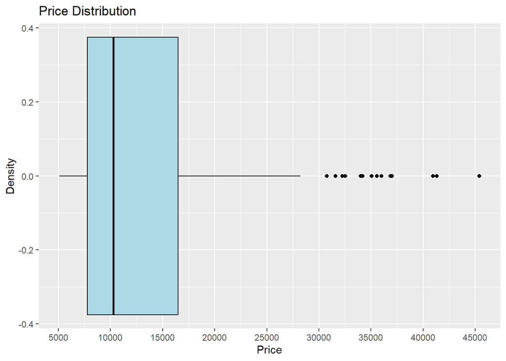

```r
ggplot(cars, aes(x = price)) +
  geom_boxplot(color = "black", fill = "lightblue") +
  labs(title = "Price Distribution", x = "Price", y = "Density") +
  scale_x_continuous(name = "Price", breaks = seq(0, 50000, by = 5000))
```

```r
Q1 <- quantile(cars$price, probs = 0.25)
Q3 <- quantile(cars$price, probs = 0.75)
iqr <- IQR(x = cars$price)

lower_bound <- Q1 - (1.5 * iqr)
upper_bound <- Q3 + (1.5 * iqr)
outliers <- cars$price[cars$price < lower_bound | cars$price > upper_bound]
outliers
```

```
 [1] 30760 41315 36880 32250 35550 36000 31600 34184 35056 40960 45400 32528
[13] 34028 37028
```

# Recoding the price into low, medium, high and extremely high priced cars, and converting characters to factors.

```r
cars <- cars %>%
  mutate(
    price_cat = case_when(
      price <= 7785 ~ "cheap_cars",
      price > 7785 & price <= 16500 ~ "affordable_cars",
      price > 16500 & price <= 30000 ~ "high_priced_cars",
      price > 30000 ~ "e_high_priced_cars",
    )
  )

char_cols <- c("make", "fuel_type", "aspiration", "num_of_doors", "body_style", "drive_wheels", "engine_location",
               "engine_type", "num_of_cylinders", "fuel_system", "na_values", "price_cat")
cars[char_cols] <- lapply(cars[char_cols], FUN = as.factor)
```

# Exploratory Data Analysis

Now the data is ready for analysis. Clearly, the supply of Toyota cars is highest in the market, with over `30` cars. This is followed by Nissan and Mazda with just under `20` in the market. Mitsubishi, Honda, Volkswagen, Subaru, Volvo and Peugeot have supplies under `15` cars in the market. Whereas, Dodge, Mercedes-benz, BMW, Plymouth, Audi, Saab, Porsche, Isuzu, Jaguar, Chevrolet, Renault, Alfa-romero and Mecury have the least supplied in the market, under `10` cars.

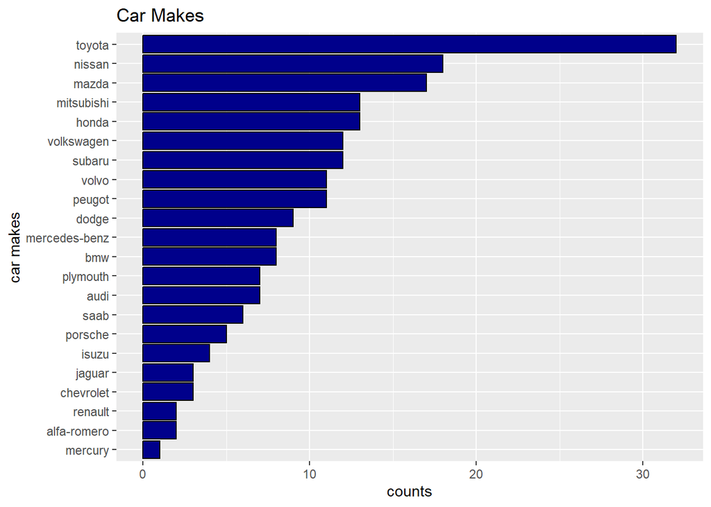

```r
# Which car makers have the most cars in the data?
# Preprocess the data
car_counts <- cars %>%
  count(make) %>%
  arrange(desc(n))

car_counts$make <- reorder(car_counts$make, car_counts$n, FUN = max)

ggplot(data = car_counts, aes(y = make, x = n)) +
  geom_bar(stat = "identity", color = "black", fill = "darkblue") +
  labs(title = "Car Makes", x = "counts", y = "car makes")
```

Which car makes costs the most?

```r
# Extrement high priced cars
e_high_priced_car_counts <- cars %>%
  filter(price_cat == "e_high_priced_cars") %>%
  group_by(price_cat, make) %>%
  count(make) %>%
  arrange(desc(n))
e_high_priced_car_counts
```

| price_cat | make | n |
| --- | --- | --- |
| e_high_priced_cars | mercedes-benz | 5 |
| e_high_priced_cars | bmw | 3 |
| e_high_priced_cars | jaguar | 3 |
| e_high_priced_cars | porsche | 3 |

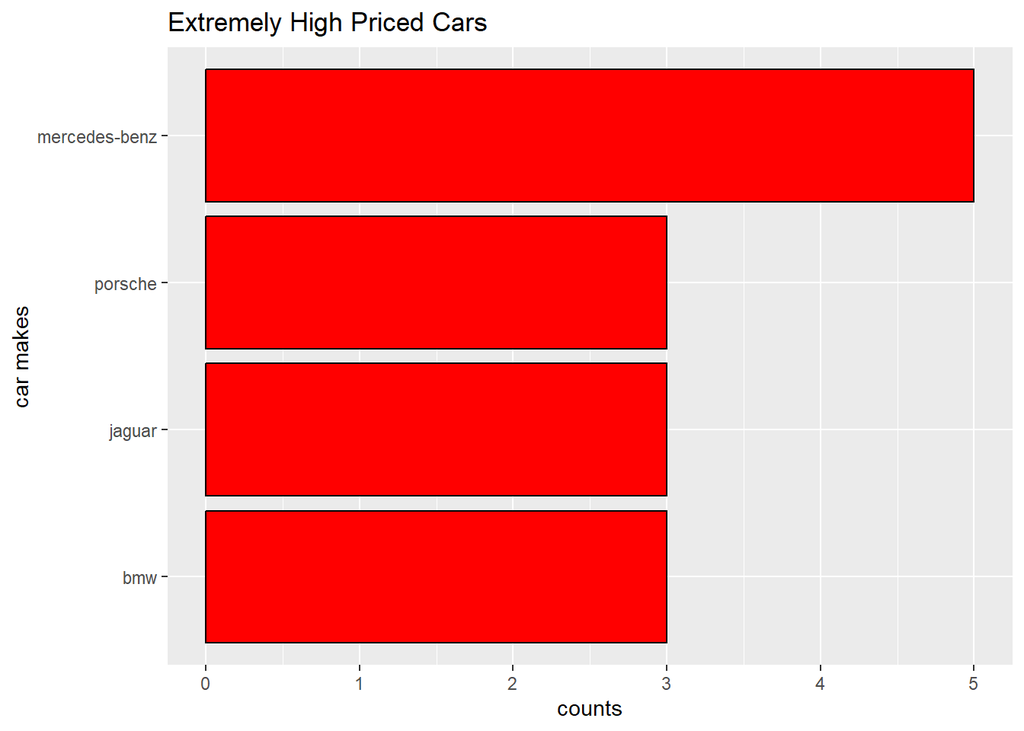

```r
e_high_priced_car_counts$make <- reorder(e_high_priced_car_counts$make, e_high_priced_car_counts$n, FUN = max)
ggplot(data = e_high_priced_car_counts, aes(y = make, x = n)) +
  geom_bar(stat = "identity", color = "black", fill = "red") +
  labs(title = "Extremely High Priced Cars", x = "counts", y = "car makes")
```

```r
# High priced cars
high_priced_car_counts <- cars %>%
  filter(price_cat == "high_priced_cars") %>%
  group_by(price_cat, make) %>%
  count(make) %>%
  arrange(desc(n))
high_priced_car_counts
```

| price_cat | make | n |
| --- | --- | --- |
| high_priced_cars | volvo | 8 |
| high_priced_cars | peugot | 6 |
| high_priced_cars | audi | 4 |
| high_priced_cars | bmw | 4 |
| high_priced_cars | mercedes-benz | 3 |
| high_priced_cars | nissan | 3 |
| high_priced_cars | mazda | 2 |
| high_priced_cars | saab | 2 |
| high_priced_cars | toyota | 2 |
| high_priced_cars | mercury | 1 |

[output cut: 1 more lines]

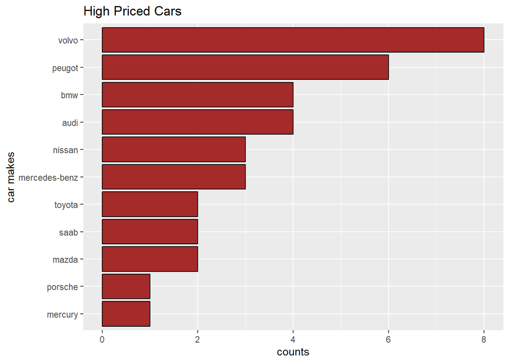

```r
high_priced_car_counts$make <- reorder(high_priced_car_counts$make, high_priced_car_counts$n, FUN = max)
ggplot(data = high_priced_car_counts, aes(y = make, x = n)) +
  geom_bar(stat = "identity", color = "black", fill = "brown") +
  labs(title = "High Priced Cars", x = "counts", y = "car makes")
```

```r
# Affordable cars
affordable_car_counts <- cars %>%
  filter(price_cat == "affordable_cars") %>%
  group_by(price_cat, make) %>%
  count(make) %>%
  arrange(desc(n))
affordable_car_counts
```

| price_cat | make | n |
| --- | --- | --- |
| affordable_cars | toyota | 23 |
| affordable_cars | volkswagen | 11 |
| affordable_cars | mazda | 10 |
| affordable_cars | mitsubishi | 8 |
| affordable_cars | nissan | 8 |
| affordable_cars | honda | 6 |
| affordable_cars | subaru | 6 |
| affordable_cars | peugot | 5 |
| affordable_cars | dodge | 4 |
| affordable_cars | saab | 4 |

[output cut: 8 more lines]

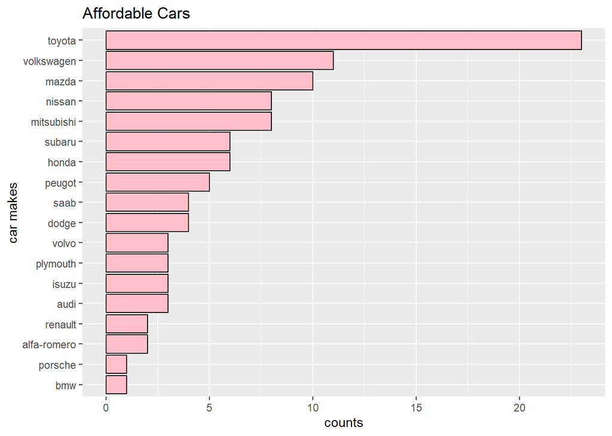

```r
affordable_car_counts$make <- reorder(affordable_car_counts$make, affordable_car_counts$n, FUN = max)
ggplot(data = affordable_car_counts, aes(y = make, x = n)) +
  geom_bar(stat = "identity", color = "black", fill = "pink") +
  labs(title = "Affordable Cars", x = "counts", y = "car makes")
```

```r
# Cheap cars
cheap_car_counts <- cars %>%
  filter(price_cat == "cheap_cars") %>%
  group_by(price_cat, make) %>%
  count(make) %>%
  arrange(desc(n))
cheap_car_counts
```

| price_cat | make | n |
| --- | --- | --- |
| cheap_cars | honda | 7 |
| cheap_cars | nissan | 7 |
| cheap_cars | toyota | 7 |
| cheap_cars | subaru | 6 |
| cheap_cars | dodge | 5 |
| cheap_cars | mazda | 5 |
| cheap_cars | mitsubishi | 5 |
| cheap_cars | plymouth | 4 |
| cheap_cars | chevrolet | 3 |
| cheap_cars | isuzu | 1 |

[output cut: 1 more lines]

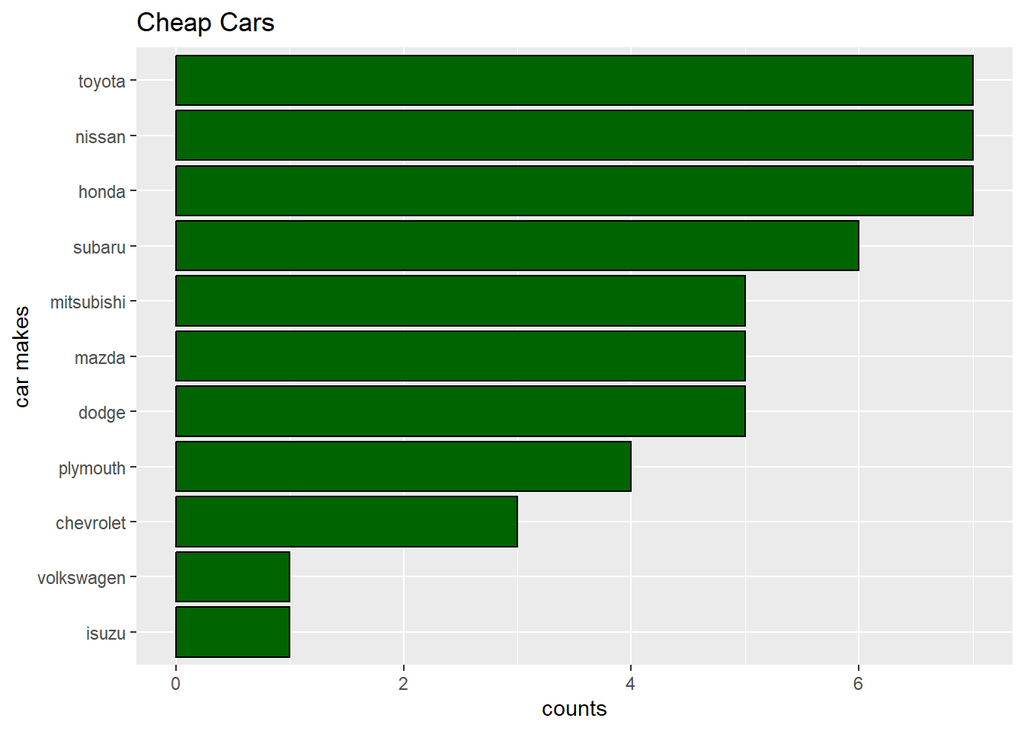

```r
cheap_car_counts$make <- reorder(cheap_car_counts$make, cheap_car_counts$n, FUN = max)
ggplot(data = cheap_car_counts, aes(y = make, x = n)) +
  geom_bar(stat = "identity", color = "black", fill = "darkgreen") +
  labs(title = "Cheap Cars", x = "counts", y = "car makes")
```

# Summary Statistics

```r
factor_cols <- cars %>% select_if(is.factor) %>% names()
numeric_cols <- cars %>% select_if(is.numeric) %>% names()
cars <- cars %>% select(c(factor_cols, numeric_cols))
summ <- statar::sum_up(cars[, -1], d = TRUE) %>%
  select(c(Variable, Obs, Mean, SD = StdDev, Min, p25, Median = p50, p75, Max))
```

```
         Variable │      Obs  Missing     Mean   StdDev Skewness Kurtosis
──────────────────┼───────────────────────────────────────────────────────
             bore │      204        0   3.3226  0.27448  0.06278  2.12301
         city_mpg │      204        0  25.2402  6.53544  0.65108  3.52357
compression_ratio │      204        0  10.1481  3.97123  2.58286   8.0297
      curb_weight │      204        0   2555.6   520.68  0.67454  2.91458
      engine_size │      204        0  126.892  41.6421  1.92982  8.11153
           height │      204        0   53.749  2.41895  0.07586  2.54177
      highway_mpg │      204        0  30.7696  6.88141  0.52868  3.38748
       horsepower │      204        0  104.132  39.5268  1.39257  5.57007
           length │      204        0  174.075  12.3318  0.14876   2.8796
normalised_losses │      204        0  120.627  31.8027  0.96425  4.41032
         peak_rpm │      204        0  5125.99  476.898  0.06909  3.04231
            price │      204        0  13148.1  7879.26  1.82373  6.23501
           stroke │      204        0  3.25324  0.31304 -0.64594  5.03833
        symboling │      204        0  0.82353  1.23599  0.21317  2.33047
       wheel_base │      204        0  98.8064  5.97943  1.06126  3.98028
            width │      204        0  65.9167  2.14145  0.89044  3.64704


         Variable │      Min       p1       p5      p10      p25      p50
──────────────────┼───────────────────────────────────────────────────────
             bore │     2.54     2.91     2.97     2.97    3.105     3.31
         city_mpg │       13       14       16       17       19       24
compression_ratio │        7        7      7.5        8     8.55        9
      curb_weight │     1488     1819     1900     1945     2145     2414
      engine_size │       61       70       90       91       97    119.5
           height │     47.8     49.4     49.7     50.6       52     54.1
      highway_mpg │       16       17       22       23       25       30
       horsepower │       48       52       62       68       70       95
           length │    141.1    144.6    157.1    157.3    166.3    173.2
normalised_losses │       65       65       77       85      101      115
         peak_rpm │     4150     4150     4250     4500     4800     5200
            price │     5118     5195     6189     6649   7781.5    10270
           stroke │     2.07     2.19     2.64      2.9    3.105     3.29
        symboling │       -2       -2       -1       -1        0        1
       wheel_base │     86.6     88.4     93.1     93.7     94.5       97
            width │     60.3     62.5     63.6     63.8    64.05     65.5


         Variable │      p50      p75      p90      p95      p99      Max
──────────────────┼───────────────────────────────────────────────────────
             bore │     3.31    3.585      3.7     3.78      3.8     3.94
         city_mpg │       24       30       32       37       45       49
compression_ratio │        9      9.4     11.5     21.9       23       23
      curb_weight │     2414   2943.5     3230     3505     3950     4066
      engine_size │    119.5      143      181      203      304      326
           height │     54.1     55.5     56.7     57.5     59.1     59.8
      highway_mpg │       30       35       38       43       50       54
       horsepower │       95      116      160      182      207      288
           length │    173.2    183.3    188.8      197    202.6    208.1
normalised_losses │      115      137      161      186      197      256
         peak_rpm │     5200     5500     5800     6000     6000     6600
            price │    10270    16500    22470    32528    40960    45400
           stroke │     3.29     3.41     3.54     3.64      3.9     4.17
        symboling │        1        2        3        3        3        3
       wheel_base │       97    102.4    107.9      110    115.6    120.9
            width │     65.5     66.9     68.8     70.5     71.7     72.3
```

```r
round_df <- function(df, digits = digits) {
  df[] <- lapply(
    df, FUN = function(x) {
      if (is.numeric(x)) round(x, digits) else x
    }
  )
  return(df)
}

round_df(summ, digits = 2)
```

| Variable | Obs | Mean | SD | Min | p25 | Median | p75 | Max |
| --- | --- | --- | --- | --- | --- | --- | --- | --- |
| bore | 204 | 3.32 | 0.27 | 2.54 | 3.10 | 3.31 | 3.58 | 3.94 |
| city_mpg | 204 | 25.24 | 6.54 | 13.00 | 19.00 | 24.00 | 30.00 | 49.00 |
| compression_ratio | 204 | 10.15 | 3.97 | 7.00 | 8.55 | 9.00 | 9.40 | 23.00 |
| curb_weight | 204 | 2555.60 | 520.68 | 1488.00 | 2145.00 | 2414.00 | 2943.50 | 4066.00 |
| engine_size | 204 | 126.89 | 41.64 | 61.00 | 97.00 | 119.50 | 143.00 | 326.00 |
| height | 204 | 53.75 | 2.42 | 47.80 | 52.00 | 54.10 | 55.50 | 59.80 |
| highway_mpg | 204 | 30.77 | 6.88 | 16.00 | 25.00 | 30.00 | 35.00 | 54.00 |
| horsepower | 204 | 104.13 | 39.53 | 48.00 | 70.00 | 95.00 | 116.00 | 288.00 |
| length | 204 | 174.07 | 12.33 | 141.10 | 166.30 | 173.20 | 183.30 | 208.10 |
| normalised_losses | 204 | 120.63 | 31.80 | 65.00 | 101.00 | 115.00 | 137.00 | 256.00 |

[output cut: 6 more lines]

# Correlation between numeric variables and the response variable, price

Based on the convention of r `>= 0.8` for a strong correlation, it is clearly seen that curb_weight and engine_size have the strongest correlation with car prices, and its positive. Thus, suggesting a co-movement in their relationship. Expectedly, the higher weight and car engines, the higher the price. Other strong correlation includes length, width, horsepower, city- and highway miles per gallon. This is based on r `>= 0.7`. I expected an inverse correlation between car prices and miles per gallon. A weaker threshold of r `>= 0.5` shows positive correlations between car prices and wheel base and bore.

```r
glimpse(cars)
```

```
Rows: 204
Columns: 28
Groups: make [22]
$ make              <fct> alfa-romero, alfa-romero, audi, audi, audi, audi, au…
$ fuel_type         <fct> gas, gas, gas, gas, gas, gas, gas, gas, gas, gas, ga…
$ aspiration        <fct> std, std, std, std, std, std, std, turbo, turbo, std…
$ num_of_doors      <fct> four, six, four, five, five, five, five, five, five,…
$ body_style        <fct> convertible, hatchback, sedan, sedan, sedan, sedan, …
$ engine_location   <fct> front, front, front, front, front, front, front, fro…
$ drive_wheels      <fct> rwd, rwd, fwd, 4wd, fwd, fwd, fwd, fwd, 4wd, rwd, rw…
$ engine_type       <fct> dohc, ohcv, ohc, ohc, ohc, ohc, ohc, ohc, ohc, ohc, …
$ num_of_cylinders  <fct> four, six, four, five, five, five, five, five, five,…
$ fuel_system       <fct> mpfi, mpfi, mpfi, mpfi, mpfi, mpfi, mpfi, mpfi, mpfi…
$ na_values         <fct> yes, yes, no, no, yes, no, yes, no, yes, no, no, no,…
$ price_cat         <fct> affordable_cars, affordable_cars, affordable_cars, h…
```

[output cut: 16 more lines]

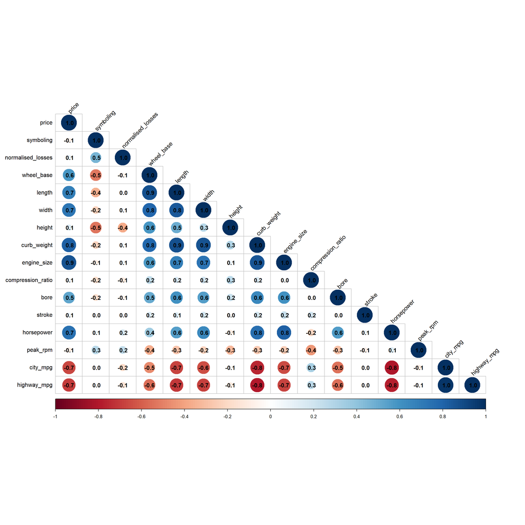

```r
num_cols <- 13:28
# Correlation matrix
corrplot(
  corr = cor(cars[num_cols], method = "pearson"),
  method = "circle",
  type = "lower",
  tl.col = "black",
  tl.srt = 45,
  addCoef.col = TRUE,
  number.digits = 1,
  win.asp = 0.65
)
```

# Correlation between factor variables and the response variable, price

I find few correlation along few factor dimensions, such as number of doors, drive wheels, number of cylinders, fuel system, and extremely high priced cars.

```r
# Convert factors to numeric dummies
fac_cols <- 2:12
dummies <- dummyVars(~., data = cars[fac_cols], fullRank = T, sep = "_")
factor_numeric <- predict(dummies, newdata = cars[fac_cols]) %>%
  data.frame() %>%
  select(-contains(match = "No"))
head(factor_numeric)
```

|  | fuel_type_gas | aspiration_turbo | num_of_doors_five | num_of_doors_four | num_of_doors_six | num_of_doors_three | num_of_doors_twelve | num_of_doors_two | body_style_hardtop | body_style_hatchback | body_style_sedan | body_style_wagon | engine_location_rear | drive_wheels_fwd | drive_wheels_rwd | engine_type_dohcv | engine_type_l | engine_type_ohc | engine_type_ohcf | engine_type_ohcv | engine_type_rotor | num_of_cylinders_five | num_of_cylinders_four | num_of_cylinders_six | num_of_cylinders_three | num_of_cylinders_twelve | num_of_cylinders_two | fuel_system_2bbl | fuel_system_4bbl | … |
| --- | --- | --- | --- | --- | --- | --- | --- | --- | --- | --- | --- | --- | --- | --- | --- | --- | --- | --- | --- | --- | --- | --- | --- | --- | --- | --- | --- | --- | --- | --- |
| 1 | 1 | 0 | 0 | 1 | 0 | 0 | 0 | 0 | 0 | 0 | 0 | 0 | 0 | 0 | 1 | 0 | 0 | 0 | 0 | 0 | 0 | 0 | 1 | 0 | 0 | 0 | 0 | 0 | 0 | … |
| 2 | 1 | 0 | 0 | 0 | 1 | 0 | 0 | 0 | 0 | 1 | 0 | 0 | 0 | 0 | 1 | 0 | 0 | 0 | 0 | 1 | 0 | 0 | 0 | 1 | 0 | 0 | 0 | 0 | 0 | … |
| 3 | 1 | 0 | 0 | 1 | 0 | 0 | 0 | 0 | 0 | 0 | 1 | 0 | 0 | 1 | 0 | 0 | 0 | 1 | 0 | 0 | 0 | 0 | 1 | 0 | 0 | 0 | 0 | 0 | 0 | … |
| 4 | 1 | 0 | 1 | 0 | 0 | 0 | 0 | 0 | 0 | 0 | 1 | 0 | 0 | 0 | 0 | 0 | 0 | 1 | 0 | 0 | 0 | 1 | 0 | 0 | 0 | 0 | 0 | 0 | 0 | … |
| 5 | 1 | 0 | 1 | 0 | 0 | 0 | 0 | 0 | 0 | 0 | 1 | 0 | 0 | 1 | 0 | 0 | 0 | 1 | 0 | 0 | 0 | 1 | 0 | 0 | 0 | 0 | 0 | 0 | 0 | … |
| 6 | 1 | 0 | 1 | 0 | 0 | 0 | 0 | 0 | 0 | 0 | 1 | 0 | 0 | 1 | 0 | 0 | 0 | 1 | 0 | 0 | 0 | 1 | 0 | 0 | 0 | 0 | 0 | 0 | 0 | … |

```r
# check for columns with 0 variance. Bind columns
names(factor_numeric)[which(rowSums(factor_numeric) == 0)]
```

```
character(0)
```

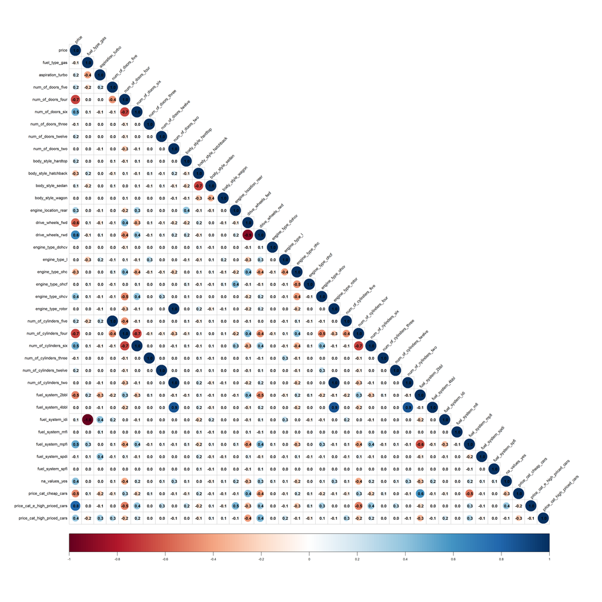

```r
cars_df <- bind_cols(cars[1], cars[num_cols], factor_numeric, cars[fac_cols])

# preprocess the data
fac_cols_new <- c(2, 18:55)
cars_df_cor <- cars_df %>% select(all_of(fac_cols_new))
cars_df_cor <- cars_df_cor[, -1]

# Correlation matrix
corrplot(
  corr = cor(cars_df_cor, method = "pearson"),
  method = "circle",
  type = "lower",
  tl.col = "black",
  tl.srt = 45,
  addCoef.col = TRUE,
  number.digits = 1,
  # win.asp = 0.8
)
```

# Training and testing data split. Set seed to make results reproducible

```r
# Split data into train and test
set.seed(seed = 123)
intrain <- createDataPartition(y = cars$price, p = 0.8, list = FALSE)
training <- cars %>% slice(intrain)
testing <- cars %>% slice(-intrain)
```